# Tech Dividends, Part 1

Author

Rick Dean

Abstract

The following notes/R scripts were inspired from an article [Tech Dividends, Part 1](https://rviews.rstudio.com/2019/08/07/tech-dividends-part1/) by Jonathan Regenstein.

```r
library(data.table)
library(ggplot2)
library(here)
library(magrittr)
library(quantmod)
library(RplotterPkg)
library(RstocksPkg)
```

Note: Be aware that this application has an internet request for dividend data that will take time to complete.

# 1 Tech Dividends, Part 1

## 1.1 The data.

NASDAQ company symbols

Read the symbols of NASDAQ companies with market cap greater than $10B. The source is [Stock Screener](https://www.nasdaq.com/market-activity/stocks/screener). We only want companies that have IPO’ed greater than 2007.

```r
symbols_file_path <- file.path(here::here(), "data", "nasdaq_mega_large_medium_small.csv")
nasdaq_symbols_dt <- data.table::fread(symbols_file_path) %>%
  .[, .(Symbol, Name, `IPO Year`, `Market Cap`, Sector)] %>%
  .[`IPO Year` > 2007,] %>%
  .[order(-`Market Cap`)]
```

Dividend prices for companies over the last 10 years.

We want to get dividend history for the top 100 NASDAQ companies based on “Market Cap”.

```r
top_nasdaq_symbols <- nasdaq_symbols_dt$Symbol[1:100]
nasdaq_dividends_dt <- RstocksPkg::get_dividends(
  symbols = top_nasdaq_symbols,
  from = "2013-01-01",
  to = "2022-12-31"
) %>%
  na.omit()
```

Add a *year* variable to our dividends data.table.

```r
nasdaq_dividends_dt[, Year := as.numeric(format(Date, "%Y"))]
RplotterPkg::create_table(
  x = nasdaq_dividends_dt[1:6,],
  container_width_px = 400
)
```

| Symbol | Date | Dividend | Year |
| --- | --- | --- | --- |
| AVGO | 2013-03-21 | 0.19 | 2013 |
| AVGO | 2013-06-13 | 0.21 | 2013 |
| AVGO | 2013-09-17 | 0.23 | 2013 |
| AVGO | 2013-12-18 | 0.25 | 2013 |
| AVGO | 2014-03-18 | 0.27 | 2014 |
| AVGO | 2014-06-17 | 0.29 | 2014 |

Format of current data.table with 491 NASDAQ observations posting dividends

## 1.2 First date when the companies posted a dividend.

Get the first observation from each *Symbol* grouping where a dividend was posted.

```r
first_dividend_dt <- nasdaq_dividends_dt[, .SD[1L], by = Symbol]

RplotterPkg::create_table(
  x = first_dividend_dt[1:6,],
  container_width_px = 400
)
```

First Posted Dividend Dates for Top NASDAQ Companies(21 x 4)

| Symbol | Date | Dividend | Year |
| --- | --- | --- | --- |
| AVGO | 2013-03-21 | 0.190 | 2013 |
| JD | 2022-05-19 | 1.260 | 2022 |
| NXPI | 2018-09-24 | 0.250 | 2018 |
| BNTX | 2022-06-02 | 2.111 | 2022 |
| VRSK | 2019-03-14 | 0.250 | 2019 |
| CDW | 2013-11-13 | 0.043 | 2013 |

We have a total of 21 companies with their first dividend posting dates.

## 1.3 Count for each year when a company first granted a dividend.

```r
first_dividends_year_count_dt <- first_dividend_dt[, .N, by = Year][order(Year)]

RplotterPkg::create_table(
  x = first_dividends_year_count_dt,
  container_width_px = 200
)
```

Yearly number of companies that granted a dividend (8 x 2)

| Year | N |
| --- | --- |
| 2013 | 6 |
| 2014 | 1 |
| 2015 | 1 |
| 2016 | 1 |
| 2018 | 2 |
| 2019 | 2 |
| 2020 | 5 |
| 2022 | 3 |

## 1.4 Most recent posting in each company.

Get the most recent dividend from each company:

```r
latest_dividends_dt <- nasdaq_dividends_dt[, .SD[.N], by = Symbol][order(-Dividend)]

RplotterPkg::create_table(
  x = latest_dividends_dt,
  container_width_px = 400
)
```

Most recent posting of dividends in each company(21 x 4)

| Symbol | Date | Dividend | Year |
| --- | --- | --- | --- |
| AVGO | 2022-12-19 | 4.600 | 2022 |
| FANG | 2022-11-16 | 2.260 | 2022 |
| BNTX | 2022-06-02 | 2.111 | 2022 |
| JD | 2022-05-19 | 1.260 | 2022 |
| NXPI | 2022-12-14 | 0.845 | 2022 |
| CDW | 2022-11-23 | 0.590 | 2022 |
| CG | 2022-11-17 | 0.325 | 2022 |
| VRSK | 2022-12-14 | 0.310 | 2022 |
| LPLA | 2022-11-09 | 0.250 | 2022 |
| REYN | 2022-11-15 | 0.230 | 2022 |
| HTHT | 2022-03-23 | 0.210 | 2022 |
| SSNC | 2022-11-30 | 0.200 | 2022 |
| RPRX | 2022-11-17 | 0.190 | 2022 |
| WING | 2022-11-09 | 0.190 | 2022 |
| WMG | 2022-11-21 | 0.160 | 2022 |
| AGNC | 2022-12-29 | 0.120 | 2022 |
| IBKR | 2022-11-30 | 0.100 | 2022 |
| NFE | 2022-12-06 | 0.100 | 2022 |
| TW | 2022-11-30 | 0.080 | 2022 |
| ASO | 2022-12-19 | 0.075 | 2022 |
| BSY | 2022-11-29 | 0.030 | 2022 |

Plot the most recent dividends posted in 2022.

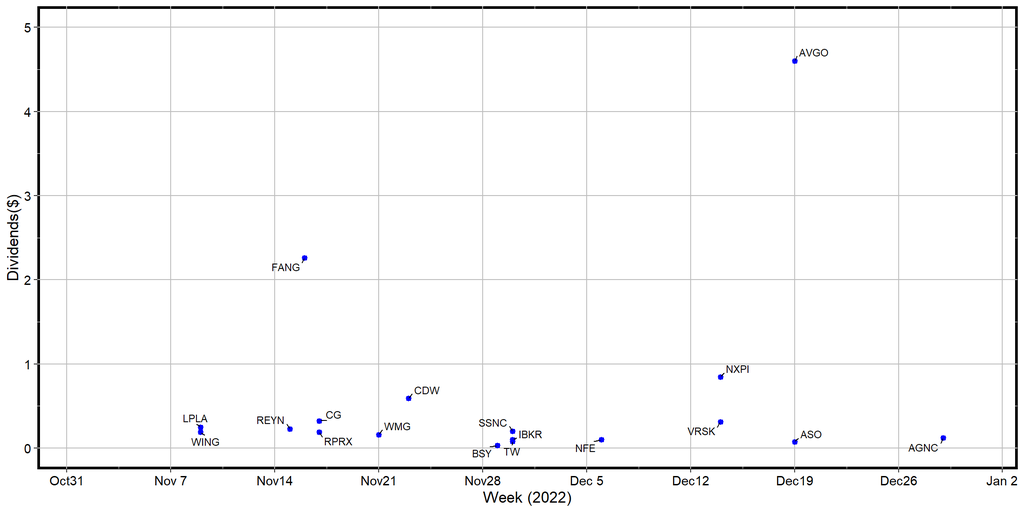

Last Dividends Paid by NASDAQ Companies in year 2022

```r
RplotterPkg::create_scatter_plot(
  df = latest_dividends_dt,
  aes_x = "Date",
  aes_y = "Dividend",
  aes_label = "Symbol",
  aes_label_size = 3,
  x_title = "Week (2022)",
  y_title = "Dividends($)",
  rot_y_tic_label = TRUE,
  x_limits = c(as.Date("2022-11-01"), as.Date("2022-12-31")),
  x_major_date_breaks = "1 week",
  x_date_labels = "%b%e",
  y_limits = c(0.0, 5.0),
  y_major_breaks = seq(0.0, 5.0, 1.0),
  pts_size = 1.2,
  pts_color = "blue",
  pts_fill = "blue",
  show_minor_grids = F
)
```

## 1.5 Plot all the dividends posted by each company

The above data.table *nasdaq_dividends_dt* has 491 observations from the top 100 NASDAQ companies from 2013-01-01 to 2022-12-31. Create a scatter plot of all these companies.

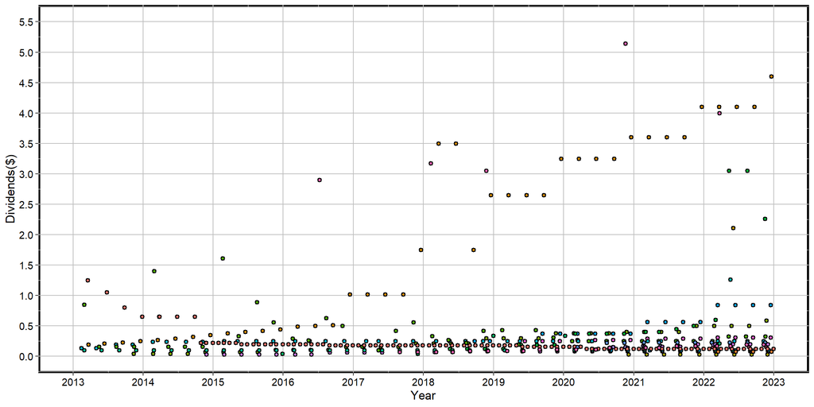

```r
RplotterPkg::create_scatter_plot(
  df = nasdaq_dividends_dt,
  aes_x = "Date",
  aes_y = "Dividend",
  aes_fill = "Symbol",
  x_title = "Year",
  y_title = "Dividends($)",
  rot_y_tic_label = TRUE,
  x_limits = c(as.Date("2013-01-01"), as.Date("2022-12-31")),
  x_major_date_breaks = "1 year",
  x_date_labels = "%Y",
  y_limits = c(0.0, 5.5),
  y_major_breaks = seq(0.0,5.5,0.5),
  pts_size = 1.2,
  show_minor_grids = F,
  show_legend = F
)
```

## 1.6 Grouped statistical summaries

Dividend stats by company

Compute descriptive statistics on *Dividend* for the 21 top companies from *nasdaq_dividends_dt*.

```r
stats_comp_dividends_dt <- nasdaq_dividends_dt[, .(N = .N, Mean = mean(Dividend), Median = median(Dividend),  Min = min(Dividend), Max = max(Dividend), Total = sum(Dividend)), by = Symbol][order(-Total)]

RplotterPkg::create_table(
  x = stats_comp_dividends_dt,
  container_width_px = 600
)
```

Dividend Statistics for top NASDAQ Companies (21 x 7)

| Symbol | N | Mean | Median | Min | Max | Total |
| --- | --- | --- | --- | --- | --- | --- |
| AVGO | 40 | 1.9707500 | 1.750 | 0.19000 | 4.600 | 78.83000 |
| AGNC | 107 | 0.2107477 | 0.180 | 0.12000 | 1.250 | 22.55000 |
| WING | 26 | 0.8007692 | 0.140 | 0.07000 | 5.140 | 20.82000 |
| CG | 40 | 0.3836250 | 0.265 | 0.10000 | 1.610 | 15.34500 |
| FANG | 19 | 0.6986316 | 0.375 | 0.12500 | 3.050 | 13.27400 |
| LPLA | 40 | 0.2402500 | 0.250 | 0.13500 | 0.250 | 9.61000 |
| CDW | 37 | 0.2498919 | 0.210 | 0.04300 | 0.590 | 9.24600 |
| NXPI | 18 | 0.4934444 | 0.375 | 0.25000 | 0.845 | 8.88200 |
| VRSK | 16 | 0.2800000 | 0.280 | 0.25000 | 0.310 | 4.48000 |
| IBKR | 39 | 0.1000000 | 0.100 | 0.10000 | 0.100 | 3.90000 |
| SSNC | 33 | 0.1013864 | 0.080 | 0.03125 | 0.200 | 3.34575 |
| REYN | 11 | 0.2209091 | 0.230 | 0.15000 | 0.230 | 2.43000 |
| BNTX | 1 | 2.1110000 | 2.111 | 2.11100 | 2.111 | 2.11100 |
| RPRX | 10 | 0.1740000 | 0.170 | 0.15000 | 0.190 | 1.74000 |
| WMG | 10 | 0.1400000 | 0.150 | 0.12000 | 0.160 | 1.40000 |
| JD | 1 | 1.2600000 | 1.260 | 1.26000 | 1.260 | 1.26000 |
| TW | 15 | 0.0800000 | 0.080 | 0.08000 | 0.080 | 1.20000 |
| NFE | 10 | 0.1000000 | 0.100 | 0.10000 | 0.100 | 1.00000 |
| HTHT | 5 | 0.1945000 | 0.210 | 0.04000 | 0.340 | 0.97250 |
| ASO | 4 | 0.0750000 | 0.075 | 0.07500 | 0.075 | 0.30000 |
| BSY | 9 | 0.0300000 | 0.030 | 0.03000 | 0.030 | 0.27000 |

This is an interesting table where for example we can see that the ticker “AGNC” posted dividends 107 times with an average amount of 0.21 and a total of 22.55 over the 2013 to 2022 time frame.

Dividend stats by year

```r
stats_year_dividends_dt <- nasdaq_dividends_dt[, .(N = .N, Mean = mean(Dividend), Median = median(Dividend), Min = min(Dividend), Max = max(Dividend), Total = sum(Dividend)), by = Year][order(Year)]

RplotterPkg::create_table(
  x = stats_year_dividends_dt,
  container_width_px = 600
)
```

| Year | N | Mean | Median | Min | Max | Total |
| --- | --- | --- | --- | --- | --- | --- |
| 2013 | 21 | 0.3358571 | 0.190 | 0.04300 | 1.25 | 7.05300 |
| 2014 | 28 | 0.2842232 | 0.220 | 0.03125 | 1.40 | 7.95825 |
| 2015 | 37 | 0.2537703 | 0.200 | 0.03125 | 1.61 | 9.38950 |
| 2016 | 37 | 0.3100676 | 0.200 | 0.03125 | 2.90 | 11.47250 |
| 2017 | 39 | 0.2755385 | 0.180 | 0.04000 | 1.75 | 10.74600 |
| 2018 | 48 | 0.5245833 | 0.180 | 0.07000 | 3.50 | 25.18000 |
| 2019 | 54 | 0.3912778 | 0.184 | 0.08000 | 3.25 | 21.12900 |
| 2020 | 67 | 0.4623881 | 0.160 | 0.03000 | 5.14 | 30.98000 |
| 2021 | 76 | 0.3931842 | 0.170 | 0.03000 | 4.10 | 29.88200 |
| 2022 | 84 | 0.5854286 | 0.190 | 0.03000 | 4.60 | 49.17600 |

Evidently 2022 was a good year for dividends where if we held the 21 companies, then we would receive a total of 84 postings for a total of $49.18.